# emma predictions

Want to use Daniele’s emma results to see how well those work for making predictions of phenotype in a test set, from a training set.

Trying to find files. Looking in directory “big_hyps_newest_associations”

file “emma.newest.results.tair9.csv”

```r
datadir <- ("~/Documents/Lab Data/Daniele/big_hyps/big_hyps_newest_associations/")
tair <- read.csv(file.path(datadir,"emma.newest.results.TAIR9.csv"))
summary(tair)
```

```
   Chromosome      Positions             high              low.resp
 Min.   :1.000   Min.   :     657   Min.   :0.0000001   Min.   :0.0000014
 1st Qu.:2.000   1st Qu.: 6185178   1st Qu.:0.2454048   1st Qu.:0.2430054
 Median :3.000   Median :11469772   Median :0.4954403   Median :0.4945850
 Mean   :3.053   Mean   :12305746   Mean   :0.4965850   Mean   :0.4959473
 3rd Qu.:4.000   3rd Qu.:17941250   3rd Qu.:0.7482937   3rd Qu.:0.7478301
 Max.   :5.000   Max.   :30425061   Max.   :0.9999967   Max.   :0.9999901
      low                slope               resid
 Min.   :0.0000014   Min.   :0.0000001   Min.   :0.0000007
 1st Qu.:0.2434737   1st Qu.:0.2459803   1st Qu.:0.2341944
 Median :0.4938458   Median :0.4965914   Median :0.4857893
 Mean   :0.4955810   Mean   :0.4978267   Mean   :0.4897370
 3rd Qu.:0.7471442   3rd Qu.:0.7499480   3rd Qu.:0.7429701
 Max.   :0.9999980   Max.   :0.9999977   Max.   :0.9999992
```

These are p-values, not effect sizes

Try loading in some .Rdata images

```r
load("~/Documents/Lab Data/Daniele/big_hyps/big_hyps_newest_associations/Dec12_2011.RData")
```

Yes this is where the info is…

```r
dim(snps) #snp info
```

```
[1] 214548    169
```

```r
dim(emma.newest.results)
```

```
[1] 214548      7
```

```r
head(emma.newest.results)
```

|  | Chromosome | Position | high | low.resp | low | slope | resid |
| --- | --- | --- | --- | --- | --- | --- | --- |
| 1 | 1 | 657 | 0.06639398 | 0.2311219 | 0.1916300 | 0.1383490 | 0.6799628 |
| 2 | 1 | 3102 | 0.13623615 | 0.5395954 | 0.1699135 | 0.2423012 | 0.4201173 |
| 3 | 1 | 4648 | 0.05497141 | 0.2509064 | 0.1495535 | 0.1053692 | 0.6173454 |
| 4 | 1 | 4880 | 0.70430312 | 0.4432039 | 0.9943314 | 0.5918783 | 0.5480897 |
| 5 | 1 | 5975 | 0.29005315 | 0.4510380 | 0.4475049 | 0.6458021 | 0.9461305 |
| 6 | 1 | 6063 | 0.67192701 | 0.8116765 | 0.5514906 | 0.6236039 | 0.3223677 |

```r
dim(emma.newest.results.TAIR9)
```

```
[1] 214548      7
```

```r
head(emma.newest.results.TAIR9)
```

|  | Chromosome | Positions | high | low.resp | low | slope | resid |
| --- | --- | --- | --- | --- | --- | --- | --- |
| 1 | 1 | 657 | 0.06639398 | 0.2311219 | 0.1916300 | 0.1383490 | 0.6799628 |
| 2 | 1 | 3102 | 0.13623615 | 0.5395954 | 0.1699135 | 0.2423012 | 0.4201173 |
| 3 | 1 | 4648 | 0.05497141 | 0.2509064 | 0.1495535 | 0.1053692 | 0.6173454 |
| 4 | 1 | 4880 | 0.70430312 | 0.4432039 | 0.9943314 | 0.5918783 | 0.5480897 |
| 5 | 1 | 5975 | 0.29005315 | 0.4510380 | 0.4475049 | 0.6458021 | 0.9461305 |
| 6 | 1 | 6063 | 0.67192701 | 0.8116765 | 0.5514906 | 0.6236039 | 0.3223677 |

```r
dim(emma.newest.results.TAIR9.filtered) # too short
```

```
[1] 176652      7
```

Since the “snps” object and the “emma.newest.results” and “emma.newest.results.TAIR9” objects all have the same nrow I am going to *assume* that everything is in the same order.

Difference between TAIR9 version?

```r
all(emma.newest.results$Position==emma.newest.results.TAIR9$Positions)
```

```
[1] FALSE
```

```r
all(emma.newest.results$Chromosome==emma.newest.results.TAIR9$Chromosome)
```

```
[1] TRUE
```

Postions don’t line up but chromosomes do. Shouldn’t matter for my analysis

Are the different emma.N objects per chromosome?

```r
sum(sapply(ls(pattern="emma\\.[1-5]$"),function(x) nrow(get(x))))
```

```
[1] 214548
```

yes. and the emma.n.f are the filtered version of the above.

```r
head(newest.high.ML.emma)
```

```
           [,1]
[1,] 0.06639398
[2,] 0.13623615
[3,] 0.05497141
[4,] 0.70430312
[5,] 0.29005315
[6,] 0.67192701
```

```r
head(emma.newest.results)
```

|  | Chromosome | Position | high | low.resp | low | slope | resid |
| --- | --- | --- | --- | --- | --- | --- | --- |
| 1 | 1 | 657 | 0.06639398 | 0.2311219 | 0.1916300 | 0.1383490 | 0.6799628 |
| 2 | 1 | 3102 | 0.13623615 | 0.5395954 | 0.1699135 | 0.2423012 | 0.4201173 |
| 3 | 1 | 4648 | 0.05497141 | 0.2509064 | 0.1495535 | 0.1053692 | 0.6173454 |
| 4 | 1 | 4880 | 0.70430312 | 0.4432039 | 0.9943314 | 0.5918783 | 0.5480897 |
| 5 | 1 | 5975 | 0.29005315 | 0.4510380 | 0.4475049 | 0.6458021 | 0.9461305 |
| 6 | 1 | 6063 | 0.67192701 | 0.8116765 | 0.5514906 | 0.6236039 | 0.3223677 |

```r
all(emma.newest.results$high==newest.high.ML.emma[,1])
```

```
[1] TRUE
```

OK but I still can’t find effects for the full emma run…

I think this is because they weren’t calculated. See script “variance.components.R”

However they were calculated on the combined emma + KW list that had P < 10e-4 (528 total) so I can just use that. Would be nice to also split it back out into KW and emma, if possible. But start with all 528.

```r
cor(phenos.t[,"high.RFR"],high.fitted)
```

```
          [,1]
[1,] 0.7162607
```

What if we look at the emma only SNPs?

```r
high.effect.snps.emma <- high.effect.snps[as.character(which(-log10(emma.newest.results.TAIR9$high)>=4)),]
high.fitted.emma <- t(high.effect.snps.emma$effect %*%
  as.matrix(high.effect.snps.emma[,grep("X[0-9]",colnames(high.effect.snps.emma))]))
high.fitted.emma
```

[output not shown]

[output cut: 115 more lines]

[output not shown]

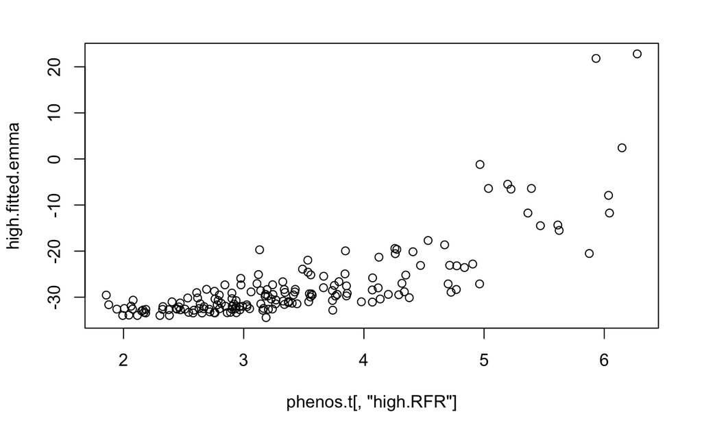

```r
plot(phenos.t[,"high.RFR"],high.fitted.emma)
```

```r
cor(phenos.t[,"high.RFR"],high.fitted.emma)
```

```
          [,1]
[1,] 0.7728612
```

```r
  mean(high.fitted.emma)
```

```
[1] -27.39874
```

Again the scale is non-sensical but the correlation is OK (Although nowhere near as good as in the Genomic Selection algorithms)

## How well does this predict test set from train?

Wait I can’t do this without re-running EMMA. And that is not going to happen…